# La distribución de Bernouli

Téllez Gerardo Rubén

1/2/2022

## Distribución de Bernouli

Si $X$ es variable aleatoria que mide el “número de éxitos” y se realiza un único experimento con dos posibles resultados (éxito de valor 1, o fracaso, de valor 0), diremos que $X$ se distribuye como una Bernouli con parámetro $p$

$$X \sim Be(p)$$

donde $p$ es la probabilidad de éxito, y $q = 1 - p$ es la probabilidad de fracaso.

- El dominio de X será $X(\Omega) = {0,1}$
- La función de probabilidad vendrá dada por

$$f(k) = p^k (1-p)^{1-k} = \Bigg \{ \begin{matrix} p & si\ k = 1 \\ 1-p & si\ k = 0 \\ 0 & en\ cualquier\ otro\ caso \end{matrix}$$

Se entiende como éxito el suceso que nos interesa estudiar.

- La función de distribución vendrá dada por

$$F(k) = \Bigg \{ \begin{matrix} 0 & si\ k < 0 \\ q & si\ 0 \le k \le 1 \\ 1 & si\ k \ge 1 \end{matrix}$$
+ Esperanza $E(X) = p$ + Varianza $Var(X) = pq$, $q = 1-p$

## Esperanza

Ya que:

$$E(X) = \sum_{x \in D_X}{x \times f(x)}$$

$$E(X) = (0 \times f(0)) + (1 \times f(1))$$
Suponiendo que el $p(éxito) = 0.5$

$$E(X) = (0 \times 0.5) + (1 \times 0.5) = 0 + 0.5 = 0.5 = p$$

## Varianza

$$Var(X) = E(X^2) - (E(X))^2$$

$$Var(X) = (0^2 \times 0.5 + 1^2 \times 0.5) - (0.5)^2 = (0.5) - 0.25 = 0.25$$

$$Var(X) = p \times (1-p) = 0.5 \times 0.5 = 0.25$$

Queda demostrado.

## Distribución de Bernoulli

El código de la distribución de Bernoulli:

- En **R** tenemos las funciones del paquete `Rlab: dbenr(x,prob), pbenr(q,prob), qbenr(), rbenr(n, prob)` donde `prob` es la probabilidad de éxito.
- En `Python` tenemos las funciones del paquete `scipy.stats.bernoulli: pmf(k,p), cdf(k,p), ppf(q,p), rvs(p, size)` donde `p` es la probabilidad de éxito.

## Ejemplos en R

### Función de densidad

$$f(k) = p^k(1-p)^{1-p}, k\in \{0,1 \}$$

Donde $p$ es la probabilidad de éxito.

Sea $X = Be(p = 0.7)$, (70% probabilidad de éxito)

```r
paste("Probabilidad de sacar 0 =",Rlab::dbern(0, 0.7)) #Probabilidad de sacar 0
```

```
## [1] "Probabilidad de sacar 0 = 0.3"
```

```r
paste("Probabilidad de sacar 1 =",Rlab::dbern(1, 0.7))#Probabilidad de sacar 1
```

```
## [1] "Probabilidad de sacar 1 = 0.7"
```

### Función de distribución o acumulada.

```r
Rlab::pbern(0, prob = 0.7) #Probabilidad acumulada de sacar 0 es el 0.3
```

```
## [1] 0.3
```

```r
Rlab::pbern(1, prob = 0.7) #Probabilidad acumulada de sacar 1 (o probabilidad de sacar 0 o 1) es el 1.
```

```
## [1] 1
```

### Sacar los cuantiles

```r
Rlab::qbern(p = c(0.5), prob = 0.7) #Mediana de la distribución es 1 al ser este el 0.7/1
```

```
## [1] 1
```

```r
Rlab::qbern(p = c(0.25), prob = 0.7) #Primer cuartil
```

```
## [1] 0
```

### Sacar valores aleatorios

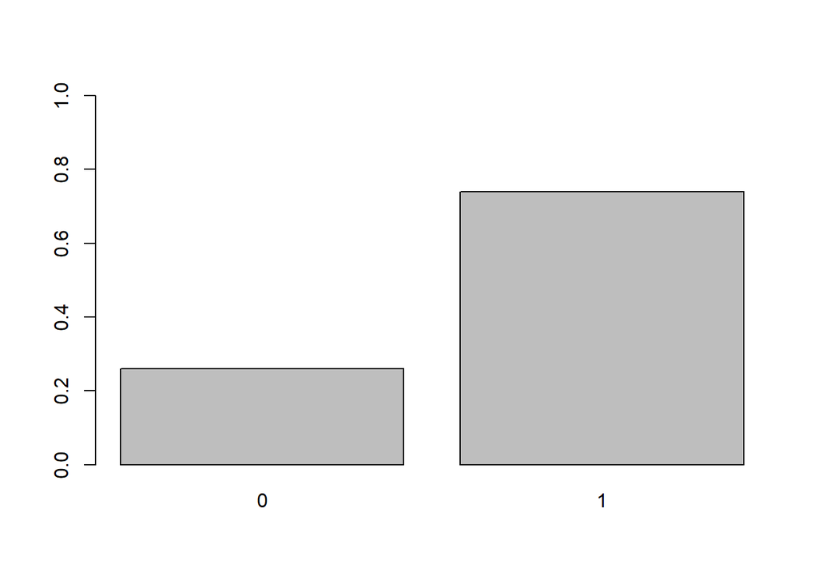

```r
Rlab::rbern(100, prob = 0.7) -> dat
barplot(prop.table(table(dat)), ylim=c(0, 1))
```

## Ejemplos en Python

```python
from scipy.stats import bernoulli
import matplotlib.pyplot as plt

p = 0.7

#La función stats genera bastantes valores

mean, var, skew, kurt = bernoulli.stats(p, moments="mvsk")

print("Media:", mean)
```

```
## Media: 0.7
```

```python
print("Varianza:", var)
```

```
## Varianza: 0.21000000000000002
```

```python
print("Sesgo:", skew)
```

```
## Sesgo: -0.8728715609439702
```

```python
print("Curtosis:", kurt)
```

```
## Curtosis: -1.2380952380952361
```

```python
fix, ax = plt.subplots(1,1)
x = bernoulli.rvs(p, size=1000)
ax.hist(x)
```

```
## (array([310.,   0.,   0.,   0.,   0.,   0.,   0.,   0.,   0., 690.]), array([0. , 0.1, 0.2, 0.3, 0.4, 0.5, 0.6, 0.7, 0.8, 0.9, 1. ]), <BarContainer object of 10 artists>)
```

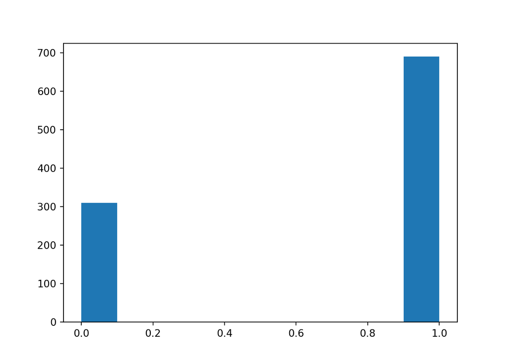

```python
plt.show()
```